# Programming with Data Mid-term Coursework

## An introduction to the research space

### Aims and objectives:

To find out if capital punishment is effective in reducing crime.

### Summary of the area of research:

In the past decades, the world has been moving away from capital punishment. As of now, more than 70% of the world's countries has abolished the death penalty in law or practice.

However, the death penalty still exist within countries with larger populations, namely the United States and China. Their reasoning is that it serves as a form of deterrence to scare potential criminals from performing any acts of crime. Also, they believe that by performing serious crimes such as murdering someone else, they have given up on human rights, including their own right to live.

On the other hand, many countries consider capital punishment cruel and an unviable form of crime control. They argue that the death penalty does not solve the root of a city's crime problem. Additionally, they believe that implementing the death penalty is counterintuitve in the moral message that it conveys, which is to fight for life and to protect a nation's people. Thus, the choose to focus on rehabilitation and restorative justice, rather than retributive justice.

### Why the field is of interest/relevant:

Personally, I chose this field as my topic of interest, as this topic is still being hugely debated in our current day and age. As the research question has not yet been answered with there being no conclusion and a clear division in preference between many countries, I have hence decided to conduct my own research to find out if implementing capital punishment is indeed effective in reducing crime.

### My own hypothesis:

There is no correlation between implementing capital punishment and lower crime rates.

### Scope of work:

I will analyse crime rates of countries who do or do not implement the death penalty, and compare the data to see if there is a correlation between countries with capital punishment implemented does indeed have lower crime rates. Hence, I will have to analyse data of the various crime rates of countries over the years, as well as to find data on whether a country implements capital punishment.

### Data processing pipeline:

Step 1: Prepare and clean the first dataset

Step 2: Prepare and clean the second dataset

Step 4: Conclusion for analysis 1

Step 5: Perform analysis 2. Divide data into two datasets - one with active and another with abolished capital punishment. Find the average crime rate for the two for each year from 2009 to 2018. Draw line graph for further analysis and conclusion.

Step 6: Conclusion for analysis 2

## Step 1: Preparing the first dataset

### Explanation as to why this data source is appropriate for the research question posed.

This data source contains all the data for prison population for various countries over the years of 2003 to 2018. The reason why I have picked this dataset is as follows:

Firstly, its coluumn heading includes total persons held in prisons by country, counts and rates per 100,000 population. Hence, it is relevant to my research question as I can use prison population in rates as a means to indicate crime rates of a country. This is because almost all crimes, from minor to major offenses, including those that include death row, require criminals to be sent to prison. Hence, I find that it is a good indication to the number of crimes that have been committed in a country, per 100,000 population.

Secondly, I have chosen to find a data source that excludes the last two years of 2019-2020, which are years affected by the pandemic. This is because, depending on how a country handles the pandemic, crime rates have increased differently for such countries, hence skewing the dataset to various different degrees.

### Origin of first data source

This data originates from the United Nations Office on Drugs and Crime (UNODC) and is sourced from the website with url = https://dataunodc.un.org/data/prison/persons%20held%20total. The acquisition technique used is by downloading an excel sheet and changing it into a dataframe for further analysis later. This was the next best alternative as downloading it as a csv made it unable to be acquired into a data frame.

Since this data can be easily found on the web, it is from an open source. The author is anonymous.

```python
import pandas as pd
import numpy as np
import matplotlib.pyplot as plt
# import library to plot graphs later
```

```python
crime_rates_df = pd.read_excel("prison population 2003-2018.xls")
# reading exel sheet

crime_rates_df.head()
# print dataframe with excel sheet data
```

|  | Unnamed: 0 | Unnamed: 1 | Unnamed: 2 | Unnamed: 3 | 2003 | 2003.1 | 2004 | 2004.1 | 2005 | 2005.1 | ... | 2014 | 2014.1 | 2015 | 2015.1 | 2016 | 2016.1 | 2017 | 2017.1 | 2018 | 2018.1 |
| --- | --- | --- | --- | --- | --- | --- | --- | --- | --- | --- | --- | --- | --- | --- | --- | --- | --- | --- | --- | --- | --- |
| 0 | Region | Subregion | Country | Source | count | rate | count | rate | count | rate | ... | count | rate | count | rate | count | rate | count | rate | count | rate |
| 1 | Africa | Eastern Africa | Burundi | UN-CTS/WPB-ICPR | 7913 | 114.5 | 7526 | 105.5 | 7167 | 97.3 | ... | 7565 | 76.8 | 9228 | 90.8 | 10127 | 96.6 | 10093 | 93.2 | 10987 | 98.3 |
| 2 | Africa | Eastern Africa | Comoros | WPB-ICPR | NaN | NaN | NaN | NaN | NaN | NaN | ... | 120 | 15.8 | 145 | 18.7 | NaN | NaN | 191 | 23.5 | 225 | 27 |
| 3 | Africa | Eastern Africa | Djibouti | UN-CTS/WPB-ICPR | NaN | NaN | NaN | NaN | NaN | NaN | ... | NaN | NaN | 600 | 65.6 | 600 | 64.6 | 624 | 66.1 | 662 | 69 |
| 4 | Africa | Eastern Africa | Ethiopia | WPB-ICPR | NaN | NaN | 74413 | 100.2 | NaN | NaN | ... | 113727 | 115.9 | NaN | NaN | NaN | NaN | NaN | NaN | NaN | NaN |

5 rows × 36 columns

### Cleaning data frame to only include prison rates from the decade 2009 to 2018

Since there are many political and economical changes over the years which are main attributes that cause changes in crime rates, I have decided to only include data from the last decade and not before that. Also, the reason why I chose a span of ten years is because I am trying to find a more accurate and recent crime indicator for each country, however there is missing data over the years. Hence, I am trying to make the average value more accurate by using data from more years.

In the following steps, I will show how I will clean the data source to only include data from the decade 2009 to 2018.

```python
columns = ['Unnamed: 2','2009.1','2010.1','2011.1','2012.1','2013.1','2014.1','2015.1','2016.1','2017.1','2018.1',]
crime_rates_df=crime_rates_df[columns]
# extracting data from the years 2009-2018

crime_rates_df.head()
```

|  | Unnamed: 2 | 2009.1 | 2010.1 | 2011.1 | 2012.1 | 2013.1 | 2014.1 | 2015.1 | 2016.1 | 2017.1 | 2018.1 |
| --- | --- | --- | --- | --- | --- | --- | --- | --- | --- | --- | --- |
| 0 | Country | rate | rate | rate | rate | rate | rate | rate | rate | rate | rate |
| 1 | Burundi | 128.8 | 113.2 | 116.5 | 68.9 | 81.6 | 76.8 | 90.8 | 96.6 | 93.2 | 98.3 |
| 2 | Comoros | 22.3 | NaN | NaN | NaN | 27.8 | 15.8 | 18.7 | NaN | 23.5 | 27 |
| 3 | Djibouti | 63.4 | NaN | 87.8 | NaN | 62.3 | NaN | 65.6 | 64.6 | 66.1 | 69 |
| 4 | Ethiopia | NaN | 119.2 | NaN | 119.8 | NaN | 115.9 | NaN | NaN | NaN | NaN |

```python
crime_rates_df=crime_rates_df.drop(index = crime_rates_df.index[0], axis=0)
# dropping the first row

crime_rates_df = crime_rates_df.rename(columns={"Unnamed: 2": "Country", "2009.1": "2009", "2010.1": "2010",
                        "2011.1": "2011", "2012.1": "2012", "2013.1": "2013", "2014.1": "2014",
                        "2015.1": "2015", "2016.1": "2016", "2017.1": "2017", "2018.1": "2018"})
# rename columns

crime_rates_df.head()
```

|  | Country | 2009 | 2010 | 2011 | 2012 | 2013 | 2014 | 2015 | 2016 | 2017 | 2018 |
| --- | --- | --- | --- | --- | --- | --- | --- | --- | --- | --- | --- |
| 1 | Burundi | 128.8 | 113.2 | 116.5 | 68.9 | 81.6 | 76.8 | 90.8 | 96.6 | 93.2 | 98.3 |
| 2 | Comoros | 22.3 | NaN | NaN | NaN | 27.8 | 15.8 | 18.7 | NaN | 23.5 | 27 |
| 3 | Djibouti | 63.4 | NaN | 87.8 | NaN | 62.3 | NaN | 65.6 | 64.6 | 66.1 | 69 |
| 4 | Ethiopia | NaN | 119.2 | NaN | 119.8 | NaN | 115.9 | NaN | NaN | NaN | NaN |
| 5 | Kenya | 117.7 | 114.6 | 118.3 | 100.4 | 117.4 | 114.6 | 113.3 | 98.9 | 101.6 | 101.6 |

```python
mean_crimeRate = crime_rates_df.copy()
# copy to a new table to preserve original crime rate table for use later

mean_crimeRate['Mean'] = mean_crimeRate.iloc[:, 1:-1].mean(axis=1)
# finding mean value of crime rates for each country

mean_crime_rates_df = mean_crimeRate.sort_values("Mean", ascending=False)
# sort by descending for mean values

mean_crime_rates_df.index = range(225)
# arrange index in ascending order

mean_crime_rates_df.head()
```

|  | Country | 2009 | 2010 | 2011 | 2012 | 2013 | 2014 | 2015 | 2016 | 2017 | 2018 | Mean |
| --- | --- | --- | --- | --- | --- | --- | --- | --- | --- | --- | --- | --- |
| 0 | United States of America | 750.1 | 737.5 | 722.9 | 710.5 | 705.2 | 698.2 | 677.1 | 670.3 | 662.5 | NaN | 703.811111 |
| 1 | Saint Vincent and the Grenadines | 995.4 | 962 | 1174.1 | 425.9 | NaN | 378 | NaN | 422 | 426.4 | 426.4 | 683.400000 |
| 2 | Belize | 882.9 | 721.1 | 693.3 | 753.3 | 760.7 | 738.2 | 399.4 | 515.8 | 344.9 | NaN | 645.511111 |
| 3 | Seychelles | NaN | 474.7 | NaN | 675.3 | NaN | 813.8 | NaN | NaN | 440.6 | 393.8 | 601.100000 |
| 4 | Saint Kitts and Nevis | 518.4 | 575.5 | 706.1 | 732 | 660 | 654.9 | NaN | 423.1 | 423.1 | NaN | 586.637500 |

### Cleaning data frame to show country and mean

```python
columns = ['Country','Mean',]
mean_crime_rates_df = mean_crime_rates_df[columns]
# cleaning data frame to show country and mean

mean_crime_rates_df = mean_crime_rates_df.dropna()
# removing data that has null as its mean value

mean_crime_rates_df.head()
```

|  | Country | Mean |
| --- | --- | --- |
| 0 | United States of America | 703.811111 |
| 1 | Saint Vincent and the Grenadines | 683.400000 |
| 2 | Belize | 645.511111 |
| 3 | Seychelles | 601.100000 |
| 4 | Saint Kitts and Nevis | 586.637500 |

## Step 2: Preparing the second dataset

### Explanation as to why this data source is appropriate for the research question posed.

This data source is chosen as the column header includes the status of a country on whether it adopts or have abolished the death penalty in the year 2020. Hence, the information is current and serves as an accurate indicator as to whether the death penalty is still in place crime rates were recorded in the last decade, and is thus useful to the research.

### Origin of second data source

This data originates from WorldData.info and is sourced from the website with url = https://www.worlddata.info/deathpenalty.php. The acquisition technique used is by webscraping data from a php website and changing it into a dataframe for further analysis.

Since this data can be easily found on the web, it is from an open source. The author is anonymous.

```python
import requests

url="https://www.worlddata.info/deathpenalty.php"
response = requests.get(url)

response.text
```

```
'<!DOCTYPE HTML><html lang="en"><head><meta charset="utf-8"><title>Countries with statutory death penalty</title><link rel="preconnect" href="https://cdn.worlddata.info"><link rel="dns-prefetch" href="https://cdn.worlddata.info"><link rel="alternate" hreflang="de" href="https://www.laenderdaten.info…
```

```python
new_table = pd.read_html(response.text)[0]

new_table.head()
# web scraping with php
```

|  | Country | Status | Executions | Death sentences |
| --- | --- | --- | --- | --- |
| 0 | Afghanistan | active | 0 | 4 |
| 1 | Algeria | abolished in practice | 0 | 1 |
| 2 | Antigua and Barbuda | active | 0 | 0 |
| 3 | Bahamas | active | 0 | 0 |
| 4 | Bahrain | active | 0 | 3 |

```python
new_table.to_csv("Countries and death sentences")
death_sentences_df = pd.read_csv("Countries and death sentences")
# create new file to save dataset as csv

death_sentences_df.head()
```

|  | Unnamed: 0 | Country | Status | Executions | Death sentences |
| --- | --- | --- | --- | --- | --- |
| 0 | 0 | Afghanistan | active | 0 | 4 |
| 1 | 1 | Algeria | abolished in practice | 0 | 1 |
| 2 | 2 | Antigua and Barbuda | active | 0 | 0 |
| 3 | 3 | Bahamas | active | 0 | 0 |
| 4 | 4 | Bahrain | active | 0 | 3 |

### Cleaning dataframe to only show country name, and whether or not the country still adopts capital punishment

```python
columns = ['Country','Status']
death_sentences_df = death_sentences_df[columns]
# cleaning dataframe to only include country and status column

death_sentences_df.head()
```

|  | Country | Status |
| --- | --- | --- |
| 0 | Afghanistan | active |
| 1 | Algeria | abolished in practice |
| 2 | Antigua and Barbuda | active |
| 3 | Bahamas | active |
| 4 | Bahrain | active |

## Step 3: Analysis 1 - Analysing the average crime rate for each country

### Merging table to show correlation between both datasets

```python
correlation_table = pd.merge(mean_crime_rates_df, death_sentences_df, how='inner', on='Country')
# merging both datasets into one new table by using name of country as ID tag

correlation_table.head()
```

|  | Country | Mean | Status |
| --- | --- | --- | --- |
| 0 | Saint Vincent and the Grenadines | 683.400000 | active |
| 1 | Belize | 645.511111 | active |
| 2 | Saint Kitts and Nevis | 586.637500 | active |
| 3 | Cuba | 509.300000 | active |
| 4 | El Salvador | 468.555556 | only for serious crimes |

### Preparing dataframe to be used directly for analysis

Finding the median value for average crime rates to be used as a basis to split table into two sections for analysis

```python
median = correlation_table["Mean"].median()
median
```

```
120.5375
```

# Find median value

Splitting data into two tables. Data with crime rates above the median value will be labelled as countries with comparatively higher crime rates (HCR) and data with crime rates below the median value will be labelled as countries with comparatively lower crime rates (LCR).

Since there is a uneven number of rows, the median value is removed from the dataframe and excluded from both tables to ensure equal number of data for even comparison.

```python
hcr_df = correlation_table[correlation_table['Mean'] > median]
# creating a dataframe with the highest half crime rates

hcr_df
```

|  | Country | Mean | Status |
| --- | --- | --- | --- |
| 0 | Saint Vincent and the Grenadines | 683.400000 | active |
| 1 | Belize | 645.511111 | active |
| 2 | Saint Kitts and Nevis | 586.637500 | active |
| 3 | Cuba | 509.300000 | active |
| 4 | El Salvador | 468.555556 | only for serious crimes |
| 5 | Grenada | 429.800000 | abolished in practice |
| 6 | Thailand | 407.533333 | active |
| 7 | Bahamas | 387.800000 | active |
| 8 | Antigua and Barbuda | 367.850000 | active |
| 9 | Belarus | 361.000000 | active |
| 10 | Barbados | 330.122222 | active |
| 11 | Puerto Rico | 327.544444 | active |
| 12 | Saint Lucia | 316.240000 | active |
| 13 | Eswatini | 313.800000 | abolished in practice |
| 14 | Maldives | 309.000000 | abolished in practice |
| 15 | Brazil | 300.600000 | only for serious crimes |
| 16 | Chile | 300.022222 | only for serious crimes |
| 17 | Trinidad and Tobago | 280.014286 | active |
| 18 | Guyana | 276.825000 | active |
| 19 | Kazakhstan | 264.600000 | only for serious crimes |
| 20 | Israel | 255.071429 | only for serious crimes |
| 21 | Botswana | 245.511111 | active |
| 22 | Singapore | 239.833333 | active |
| 23 | Peru | 218.922222 | only for serious crimes |
| 24 | Tunisia | 217.457143 | abolished in practice |
| 25 | Bahrain | 216.460000 | active |
| 26 | Morocco | 212.187500 | abolished in practice |
| 27 | Saudi Arabia | 175.700000 | active |
| 28 | Tonga | 160.200000 | abolished in practice |
| 29 | Malaysia | 152.942857 | active |
| 30 | Jamaica | 147.012500 | active |
| 31 | Algeria | 146.085714 | abolished in practice |
| 32 | Zimbabwe | 127.166667 | active |
| 33 | Tajikistan | 123.800000 | abolished in practice |
| 34 | Kuwait | 121.262500 | active |
| 35 | Lesotho | 120.575000 | active |

```python
hcr_active = hcr_df[hcr_df['Status'].isin(['active','only for serious crimes'])]
# create dataframe which includes data for active capital punishment for countries with high crime rates

hcr_active.index = range(28)

hcr_active.head()
```

|  | Country | Mean | Status |
| --- | --- | --- | --- |
| 0 | Saint Vincent and the Grenadines | 683.400000 | active |
| 1 | Belize | 645.511111 | active |
| 2 | Saint Kitts and Nevis | 586.637500 | active |
| 3 | Cuba | 509.300000 | active |
| 4 | El Salvador | 468.555556 | only for serious crimes |

```python
hcr_abolished = hcr_df[hcr_df['Status'].isin(['abolished in practice'])]
# create dataframe which includes data for abolished capital punishment for countries with high crime rates

hcr_abolished.index = range(8)

hcr_abolished.head()
```

|  | Country | Mean | Status |
| --- | --- | --- | --- |
| 0 | Grenada | 429.800000 | abolished in practice |
| 1 | Eswatini | 313.800000 | abolished in practice |
| 2 | Maldives | 309.000000 | abolished in practice |
| 3 | Tunisia | 217.457143 | abolished in practice |
| 4 | Morocco | 212.187500 | abolished in practice |

```python
lcr_df = correlation_table[correlation_table['Mean'] < median]
# creating a dataframe with the lowest half crime rates

lcr_df.index = range(36)

lcr_df.head()
```

|  | Country | Mean | Status |
| --- | --- | --- | --- |
| 0 | Ethiopia | 118.300000 | active |
| 1 | Cameroon | 116.922222 | abolished in practice |
| 2 | Guatemala | 111.828571 | only for serious crimes |
| 3 | Libya | 111.450000 | active |
| 4 | Jordan | 111.137500 | active |

```python
lcr_active = lcr_df[lcr_df['Status'].isin(['active','only for serious crimes'])]
# create dataframe which includes data for active capital punishment for countries with low crime rates

lcr_active.index = range(24)

lcr_active.head()
```

|  | Country | Mean | Status |
| --- | --- | --- | --- |
| 0 | Ethiopia | 118.300000 | active |
| 1 | Guatemala | 111.828571 | only for serious crimes |
| 2 | Libya | 111.450000 | active |
| 3 | Jordan | 111.137500 | active |
| 4 | Uganda | 109.566667 | active |

```python
lcr_abolished = lcr_df[lcr_df['Status'].isin(['abolished in practice'])]
# create dataframe which includes data for abolished capital punishment for countries with low crime rates

lcr_abolished.index = range(12)

lcr_abolished.head()
```

|  | Country | Mean | Status |
| --- | --- | --- | --- |
| 0 | Cameroon | 116.922222 | abolished in practice |
| 1 | Kenya | 110.755556 | abolished in practice |
| 2 | Sri Lanka | 109.755556 | abolished in practice |
| 3 | Malawi | 78.666667 | abolished in practice |
| 4 | Papua New Guinea | 56.240000 | abolished in practice |

### Creating a bar graph for analysis

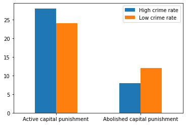

```python
hcr_active_count = len(hcr_active)
hcr_abolished_count = len(hcr_abolished)
lcr_active_count = len(lcr_active)
lcr_abolished_count = len(lcr_abolished)
# creating a python dictionary

high_crime_rate = [hcr_active_count, hcr_abolished_count]
low_crime_rate = [lcr_active_count, lcr_abolished_count]

index = ['Active capital punishment', 'Abolished capital punishment']

correlation_bargraph = pd.DataFrame({'High crime rate':high_crime_rate,'Low crime rate':low_crime_rate }, index = index )
# creating a bar graph

ax = correlation_bargraph.plot.bar(rot=0)
```